# coffe_ratings

ANHG

2023-01-23

```r
# Incluir knitr para visualización de tablas
library(knitr)
# Incluir la librería dataexplorer para exploracion de datos
library(DataExplorer)
# Tablas, librería adicional
library(kableExtra)
# Tablas páginadas customizadas
library(DT)
# Funcion para obtener datatable (datos, indice tabla, nombre)
custom_dt <- function(data, indice, nombre) {
  table_n <- paste("Table ", indice)
  dt <- datatable(data,
                  caption = htmltools::tags$caption(
                  style = 'caption-side: bottom; text-align: center;',
                  table_n, htmltools::em(nombre)),
                  extensions = 'FixedColumns',
                  rownames= FALSE,
                  filter = 'top',
                  options = list(
                  pageLength = 5,
                  autoWidth = TRUE,
                  columnDefs =
                  list(list(width = '300px', targets = c(0,7))),
                  scrollX = TRUE,
                  escape = T)
                  )
  return(dt)
}
```

# Exploración y limpieza de los datos

## Obtener Datos

```r
# install.packages("tidytuesdayR")
tuesdata <- tidytuesdayR::tt_load(2020, week = 28)
coffee_ratings_or <- tuesdata$coffee_ratings
```

## Analisis exploratorio de los datos.

```r
library(tidyverse)
custom_dt(head(coffee_ratings_or), 1, "Coffe_ratings")
```

| total_cup_points | species | owner | country_of_origin | farm_name | lot_number | mill | ico_number | company | altitude | region | producer | number_of_bags | bag_weight | in_country_partner | harvest_year | grading_date | owner_1 | variety | processing_method | aroma | flavor | aftertaste | acidity | body | balance | uniformity | clean_cup | sweetness | cupper_points | … |
| --- | --- | --- | --- | --- | --- | --- | --- | --- | --- | --- | --- | --- | --- | --- | --- | --- | --- | --- | --- | --- | --- | --- | --- | --- | --- | --- | --- | --- | --- | --- |
| 90.58 | Arabica | metad plc | Ethiopia | metad plc |  | metad plc | 2014/2015 | metad agricultural developmet plc | 1950-2200 | guji-hambela | METAD PLC | 300 | 60 kg | METAD Agricultural Development plc | 2014 | April 4th, 2015 | metad plc |  | Washed / Wet | 8.67 | 8.83 | 8.67 | 8.75 | 8.5 | 8.42 | 10 | 10 | 10 | 8.75 | … |
| 89.92 | Arabica | metad plc | Ethiopia | metad plc |  | metad plc | 2014/2015 | metad agricultural developmet plc | 1950-2200 | guji-hambela | METAD PLC | 300 | 60 kg | METAD Agricultural Development plc | 2014 | April 4th, 2015 | metad plc | Other | Washed / Wet | 8.75 | 8.67 | 8.5 | 8.58 | 8.42 | 8.42 | 10 | 10 | 10 | 8.58 | … |
| 89.75 | Arabica | grounds for health admin | Guatemala | san marcos barrancas "san cristobal cuch |  |  |  |  | 1600 - 1800 m |  |  | 5 | 1 | Specialty Coffee Association |  | May 31st, 2010 | Grounds for Health Admin | Bourbon |  | 8.42 | 8.5 | 8.42 | 8.42 | 8.33 | 8.42 | 10 | 10 | 10 | 9.25 | … |
| 89 | Arabica | yidnekachew dabessa | Ethiopia | yidnekachew dabessa coffee plantation |  | wolensu |  | yidnekachew debessa coffee plantation | 1800-2200 | oromia | Yidnekachew Dabessa Coffee Plantation | 320 | 60 kg | METAD Agricultural Development plc | 2014 | March 26th, 2015 | Yidnekachew Dabessa |  | Natural / Dry | 8.17 | 8.58 | 8.42 | 8.42 | 8.5 | 8.25 | 10 | 10 | 10 | 8.67 | … |
| 88.83 | Arabica | metad plc | Ethiopia | metad plc |  | metad plc | 2014/2015 | metad agricultural developmet plc | 1950-2200 | guji-hambela | METAD PLC | 300 | 60 kg | METAD Agricultural Development plc | 2014 | April 4th, 2015 | metad plc | Other | Washed / Wet | 8.25 | 8.5 | 8.25 | 8.5 | 8.42 | 8.33 | 10 | 10 | 10 | 8.58 | … |
| 88.83 | Arabica | ji-ae ahn | Brazil |  |  |  |  |  |  |  |  | 100 | 30 kg | Specialty Coffee Institute of Asia | 2013 | September 3rd, 2013 | Ji-Ae Ahn |  | Natural / Dry | 8.58 | 8.42 | 8.42 | 8.5 | 8.25 | 8.33 | 10 | 10 | 10 | 8.33 | … |

```r
# Rapida visualización de las columnas de datos
summary(coffee_ratings_or)
```

```
##  total_cup_points   species             owner           country_of_origin
##  Min.   : 0.00    Length:1339        Length:1339        Length:1339
##  1st Qu.:81.08    Class :character   Class :character   Class :character
##  Median :82.50    Mode  :character   Mode  :character   Mode  :character
##  Mean   :82.09
##  3rd Qu.:83.67
##  Max.   :90.58
##
##   farm_name          lot_number            mill            ico_number
##  Length:1339        Length:1339        Length:1339        Length:1339
##  Class :character   Class :character   Class :character   Class :character
##  Mode  :character   Mode  :character   Mode  :character   Mode  :character
##
##
##
##
##    company            altitude            region            producer
##  Length:1339        Length:1339        Length:1339        Length:1339
##  Class :character   Class :character   Class :character   Class :character
##  Mode  :character   Mode  :character   Mode  :character   Mode  :character
##
##
##
##
##  number_of_bags    bag_weight        in_country_partner harvest_year
##  Min.   :   0.0   Length:1339        Length:1339        Length:1339
##  1st Qu.:  14.0   Class :character   Class :character   Class :character
##  Median : 175.0   Mode  :character   Mode  :character   Mode  :character
##  Mean   : 154.2
##  3rd Qu.: 275.0
##  Max.   :1062.0
##
##  grading_date         owner_1            variety          processing_method
##  Length:1339        Length:1339        Length:1339        Length:1339
##  Class :character   Class :character   Class :character   Class :character
##  Mode  :character   Mode  :character   Mode  :character   Mode  :character
##
##
##
##
```

[output cut: 33 more lines]

```
##  Length:1339           Length:1339           Length:1339
##  Class :character      Class :character      Class :character
##  Mode  :character      Mode  :character      Mode  :character
##
##
##
##
##  altitude_low_meters altitude_high_meters altitude_mean_meters
##  Min.   :     1      Min.   :     1       Min.   :     1
##  1st Qu.:  1100      1st Qu.:  1100       1st Qu.:  1100
##  Median :  1311      Median :  1350       Median :  1311
##  Mean   :  1751      Mean   :  1799       Mean   :  1775
##  3rd Qu.:  1600      3rd Qu.:  1650       3rd Qu.:  1600
##  Max.   :190164      Max.   :190164       Max.   :190164
##  NA's   :230         NA's   :230          NA's   :230
```

## Pregunta de investigación ¿Cuales son los mejores productores de café y en qué regiones se encuentran?

Con el summary podemos ver cuáles son las variables continuas y categóricas rápidamente.

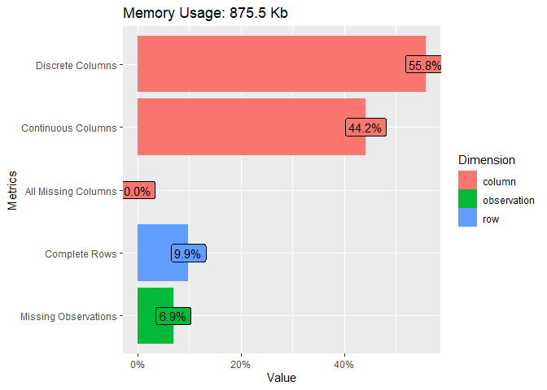

```r
# Visualización rápida de un summary de los datos
plot_intro(coffee_ratings_or)
```

¿Qué notamos?

A continuación se presenta una visualización de los valores faltantes

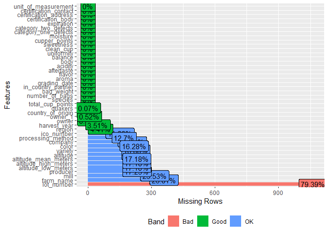

```r
plot_missing(coffee_ratings_or)
```

### Análisis de los valores faltantes

En este primer esfuerzo podemos revisar que la variable lot_number tiene un procentaje alto de faltantes, revisando el objetivo del estudio se decide descartar esta variable ya que el número de lote no abona nada para descubrir cuales son los mejores productores de café y en qué regiones se encuentran

```r
final_data <- drop_columns(coffee_ratings_or, "lot_number")
# Revisando de nuevo los missing values, pero ahora en formato de tabla obtenemos:
profile_missing(final_data)
```

```
## # A tibble: 42 × 3
##    feature           num_missing pct_missing
##    <fct>                   <int>       <dbl>
##  1 total_cup_points            0    0
##  2 species                     0    0
##  3 owner                       7    0.00523
##  4 country_of_origin           1    0.000747
##  5 farm_name                 359    0.268
##  6 mill                      315    0.235
##  7 ico_number                151    0.113
##  8 company                   209    0.156
##  9 altitude                  226    0.169
## 10 region                     59    0.0441
## # … with 32 more rows
```

### Anotaciones:

Otra cosa que observo es que hay 3 columnas con 230 datos perdidos (parece ser un patrón) por lo que filtro y me doy cuenta que casi todos los ranchos que no reportan altitud tampoco reportan estas 3.

```r
no_altitude <- final_data %>% filter(is.na(altitude_high_meters) & is.na(altitude))
custom_dt(head(no_altitude),2,"Coffy ratings excluding altitude columns")
```

| total_cup_points | species | owner | country_of_origin | farm_name | mill | ico_number | company | altitude | region | producer | number_of_bags | bag_weight | in_country_partner | harvest_year | grading_date | owner_1 | variety | processing_method | aroma | flavor | aftertaste | acidity | body | balance | uniformity | clean_cup | sweetness | cupper_points | moisture | … |
| --- | --- | --- | --- | --- | --- | --- | --- | --- | --- | --- | --- | --- | --- | --- | --- | --- | --- | --- | --- | --- | --- | --- | --- | --- | --- | --- | --- | --- | --- | --- |
| 88.83 | Arabica | ji-ae ahn | Brazil |  |  |  |  |  |  |  | 100 | 30 kg | Specialty Coffee Institute of Asia | 2013 | September 3rd, 2013 | Ji-Ae Ahn |  | Natural / Dry | 8.58 | 8.42 | 8.42 | 8.5 | 8.25 | 8.33 | 10 | 10 | 10 | 8.33 | 0.11 | … |
| 88.75 | Arabica | hugo valdivia | Peru |  | hvc |  | richmond investment-coffee department |  |  | HVC | 100 | 69 kg | Specialty Coffee Institute of Asia | 2012 | September 17th, 2012 | Hugo Valdivia | Other | Washed / Wet | 8.42 | 8.5 | 8.33 | 8.5 | 8.25 | 8.25 | 10 | 10 | 10 | 8.5 | 0.11 | … |
| 87.33 | Arabica | ethiopia commodity exchange | Ethiopia |  |  | 010/0056 |  |  | yirgacheffe | Green Gold Ethiopia \| Phone: 0114342032 | 150 | 6 | Ethiopia Commodity Exchange | 2009/2010 | June 16th, 2010 | Ethiopia Commodity Exchange |  |  | 8.17 | 8.33 | 8.25 | 8.33 | 8.42 | 8.33 | 9.33 | 10 | 9.33 | 8.83 | 0.05 | … |
| 87.08 | Arabica | ji-ae ahn | Ethiopia |  |  |  |  |  | sidamo |  | 100 | 60 kg | Specialty Coffee Institute of Asia | 2013 | September 3rd, 2013 | Ji-Ae Ahn |  | Natural / Dry | 8.42 | 8.17 | 7.92 | 8.17 | 8.33 | 8 | 10 | 10 | 10 | 8.08 | 0.11 | … |
| 86.92 | Arabica | ethiopia commodity exchange | Ethiopia |  |  | 010/0056/Sidamo |  |  | sidamo | Green Gold Ethiopia \| Phone: 0114342032 | 150 | 6 | Ethiopia Commodity Exchange | 2009/2010 | June 16th, 2010 | Ethiopia Commodity Exchange |  |  | 7.83 | 8.25 | 8.08 | 8.17 | 8.17 | 8.17 | 10 | 10 | 10 | 8.25 | 0.05 | … |
| 86.58 | Arabica | nora zeas | Nicaragua |  | beneficio atlantic condega | 790-0013 |  |  |  |  | 275 | 6 | Specialty Coffee Association |  | May 18th, 2010 | Nora Zeas |  |  | 7.92 | 8.25 | 8 | 8.33 | 8 | 8.08 | 10 | 10 | 10 | 8 | 0.08 | … |

Siguiendo el hilo de la exploración de datos, me gustaría ver como se comporta el puntaje obtenido de una taza de café con su altura.

```r
# Para ello me concentro en los datos que si tienen la altitude rellenada
final_data_con_altitude <- final_data %>% filter(!is.na(altitude_high_meters) & !is.na(altitude))

custom_dt(final_data_con_altitude, 3, "Observaciones que contienen altitud")
```

| total_cup_points | species | owner | country_of_origin | farm_name | mill | ico_number | company | altitude | region | producer | number_of_bags | bag_weight | in_country_partner | harvest_year | grading_date | owner_1 | variety | processing_method | aroma | flavor | aftertaste | acidity | body | balance | uniformity | clean_cup | sweetness | cupper_points | moisture | … |
| --- | --- | --- | --- | --- | --- | --- | --- | --- | --- | --- | --- | --- | --- | --- | --- | --- | --- | --- | --- | --- | --- | --- | --- | --- | --- | --- | --- | --- | --- | --- |
| 90.58 | Arabica | metad plc | Ethiopia | metad plc | metad plc | 2014/2015 | metad agricultural developmet plc | 1950-2200 | guji-hambela | METAD PLC | 300 | 60 kg | METAD Agricultural Development plc | 2014 | April 4th, 2015 | metad plc |  | Washed / Wet | 8.67 | 8.83 | 8.67 | 8.75 | 8.5 | 8.42 | 10 | 10 | 10 | 8.75 | 0.12 | … |
| 89.92 | Arabica | metad plc | Ethiopia | metad plc | metad plc | 2014/2015 | metad agricultural developmet plc | 1950-2200 | guji-hambela | METAD PLC | 300 | 60 kg | METAD Agricultural Development plc | 2014 | April 4th, 2015 | metad plc | Other | Washed / Wet | 8.75 | 8.67 | 8.5 | 8.58 | 8.42 | 8.42 | 10 | 10 | 10 | 8.58 | 0.12 | … |
| 89.75 | Arabica | grounds for health admin | Guatemala | san marcos barrancas "san cristobal cuch |  |  |  | 1600 - 1800 m |  |  | 5 | 1 | Specialty Coffee Association |  | May 31st, 2010 | Grounds for Health Admin | Bourbon |  | 8.42 | 8.5 | 8.42 | 8.42 | 8.33 | 8.42 | 10 | 10 | 10 | 9.25 | 0 | … |
| 89 | Arabica | yidnekachew dabessa | Ethiopia | yidnekachew dabessa coffee plantation | wolensu |  | yidnekachew debessa coffee plantation | 1800-2200 | oromia | Yidnekachew Dabessa Coffee Plantation | 320 | 60 kg | METAD Agricultural Development plc | 2014 | March 26th, 2015 | Yidnekachew Dabessa |  | Natural / Dry | 8.17 | 8.58 | 8.42 | 8.42 | 8.5 | 8.25 | 10 | 10 | 10 | 8.67 | 0.11 | … |
| 88.83 | Arabica | metad plc | Ethiopia | metad plc | metad plc | 2014/2015 | metad agricultural developmet plc | 1950-2200 | guji-hambela | METAD PLC | 300 | 60 kg | METAD Agricultural Development plc | 2014 | April 4th, 2015 | metad plc | Other | Washed / Wet | 8.25 | 8.5 | 8.25 | 8.5 | 8.42 | 8.33 | 10 | 10 | 10 | 8.58 | 0.12 | … |
| 88.67 | Arabica | ethiopia commodity exchange | Ethiopia | aolme | c.p.w.e | 010/0338 |  | 1570-1700 | oromia | Bazen Agricultural &amp; Industrial Dev't Plc | 300 | 60 kg | Ethiopia Commodity Exchange | March 2010 | September 2nd, 2010 | Ethiopia Commodity Exchange |  |  | 8.25 | 8.33 | 8.5 | 8.42 | 8.33 | 8.5 | 10 | 10 | 9.33 | 9 | 0.03 | … |
| 88.42 | Arabica | ethiopia commodity exchange | Ethiopia | aolme | c.p.w.e | 010/0338 |  | 1570-1700 | oromiya | Bazen Agricultural &amp; Industrial Dev't Plc | 300 | 60 kg | Ethiopia Commodity Exchange | March 2010 | September 2nd, 2010 | Ethiopia Commodity Exchange |  |  | 8.67 | 8.67 | 8.58 | 8.42 | 8.33 | 8.42 | 9.33 | 10 | 9.33 | 8.67 | 0.03 | … |
| 88.25 | Arabica | diamond enterprise plc | Ethiopia | tulla coffee farm | tulla coffee farm | 2014/15 | diamond enterprise plc | 1795-1850 | snnp/kaffa zone,gimbowereda | Diamond Enterprise Plc | 50 | 60 kg | METAD Agricultural Development plc | 2014 | March 30th, 2015 | Diamond Enterprise Plc | Other | Natural / Dry | 8.08 | 8.58 | 8.5 | 8.5 | 7.67 | 8.42 | 10 | 10 | 10 | 8.5 | 0.1 | … |
| 88.08 | Arabica | mohammed lalo | Ethiopia | fahem coffee plantation |  |  | fahem coffee plantation | 1855-1955 | oromia | Fahem Coffee Plantation | 300 | 60 kg | METAD Agricultural Development plc | 2014 | March 27th, 2015 | Mohammed Lalo |  | Natural / Dry | 8.17 | 8.67 | 8.25 | 8.5 | 7.75 | 8.17 | 10 | 10 | 10 | 8.58 | 0.1 | … |
| 87.92 | Arabica | cqi q coffee sample representative | United States | el filo |  | unknown | coffee quality institute | meters above sea level: 1.872 | antioquia | Alfredo De Jesús López Pérez | 10 | 1 kg | Almacafé | 2014 | March 13th, 2015 | CQI Q Coffee Sample Representative | Other | Washed / Wet | 8.25 | 8.42 | 8.17 | 8.33 | 8.08 | 8.17 | 10 | 10 | 10 | 8.5 | 0 | … |

[output cut: 1099 more lines]

Al revisar un poco los datos, veo que no todas las observaciones de altitude son numericas, por lo que decido usar altitude_mean_meters.

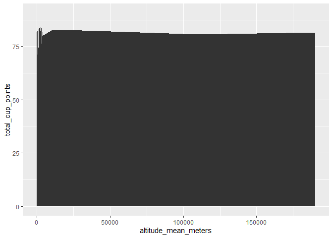

```r
final_data_con_altitude %>% ggplot(aes(x=altitude_mean_meters, y=total_cup_points)) + geom_area()
```

Si lo rellenamos por la región, se pierden un poco de información (4%), pero obtenemos indicios muy buenos del origen de los mejores cafés (apaneca y boquete) entre los 1500 y 1700 metros de altura.

Un análisis más profundo es necesario, pero esto ya representa indicios.

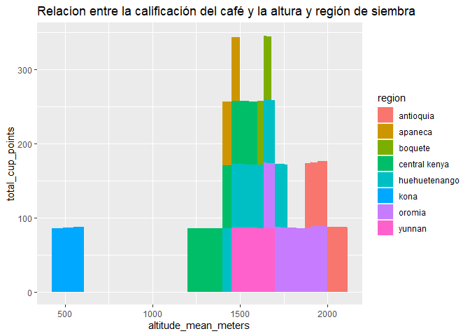

```r
final_data_con_altitude %>% filter(total_cup_points>85) %>% ggplot(aes(x=altitude_mean_meters, y=total_cup_points, fill=region)) + geom_area() + ggtitle("Relacion entre la calificación del café y la altura y región de siembra")
```

En un intento de visualizar las distribuciones de frecuencia, se tiene el inconveniente de que hay 2 columnas con datos muy largos que hacen dificil este proceso. Surge la pregunta si estos datos abonan a la pregunta de investigación (certification_address, certification_contact)

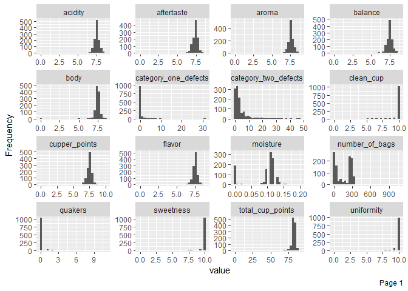

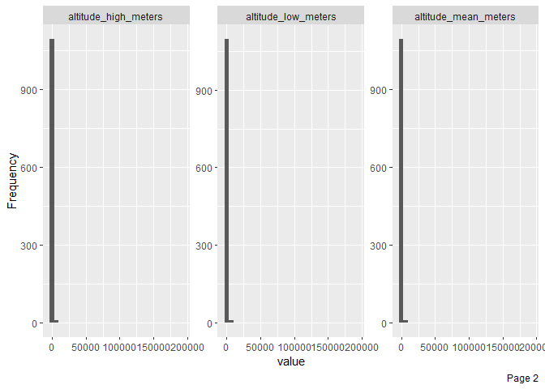

```r
plot_histogram(final_data_con_altitude)
```